# p8105_hw1_mra2209

Maya Arnott

2025-09-19

## Loading packages

```r
library(tidyverse)
library(tibble)
library(moderndive)
```

## Loading data

```r
data("early_january_weather")
```

- **origin**, indicating the weather station.
- **year**, month, day, hour, indicating the time of recording.
- **temp**, dewp, indicating the temperature and dewpoint (in F).
- **humid**, indicating the relative humidity.
- **wind_dir**, **wind_speed**, **wind_gust**, indicating the wind direction (in degrees), speed and gust speed (in mph).
- **precip**, indicating the precipitation (in inches).
- **pressure**, indicating the sea level pressure (in millibars).
- **visib**, indicating the visibility (in miles).
- **time_hour**, indicating the date and hour of the recording.

The data set has 358 rows and 15 columns. The mean temperature is 39.58 degrees Fahrenheit.

## Creating a Scatter Plot

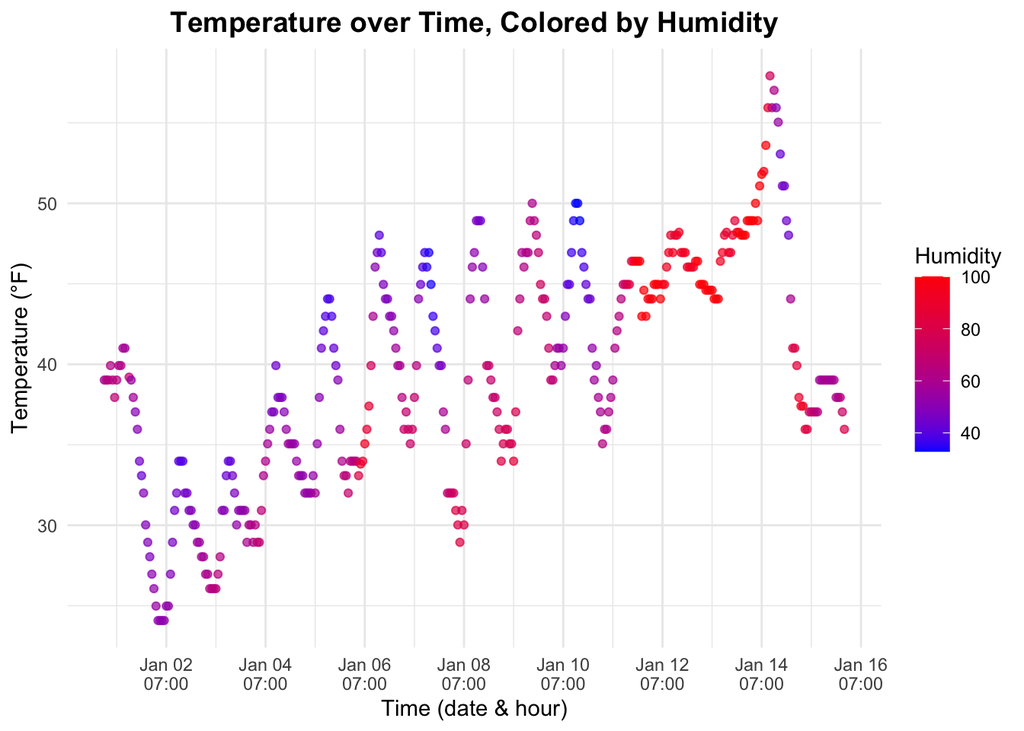

```r
weather_plot <- early_january_weather |>
  ggplot( aes ( x = time_hour, y = temp, color = humid )) +
  geom_point(alpha = 0.7) +
  labs(
      title = "Temperature over Time, Colored by Humidity",
      x = "Time (date & hour)",
      y = "Temperature (°F)",
      color = "Humidity"
  ) +
  scale_x_datetime(
    date_breaks = "48 hours",
    date_labels = "%b %d\n%H:%M"
  ) +
  theme_minimal() +
  scale_color_gradient(low = "blue", high = "red") +
  theme(plot.title = element_text(
    hjust = 0.5,
    face = "bold",
    size = 14
    )
  )

weather_plot
```

## Saving the plot using ggsave()

```r
ggsave("weather_plot.png", plot = weather_plot, width = 8, height = 5 )
```

## Creating a data frame for Problem 2

```r
my_df <- tibble (

  sample_nums = rnorm(10),

  is_positive = sample_nums > 0,

  char_vec = sample(letters, 10),

  factor_vec = factor(sample(c("Level1", "Level2", "Level3"), 10, replace = TRUE))

  )
```

## Taking the mean of each column

```r
# numerical column of size 10
mean(my_df |> pull(sample_nums), na.rm = TRUE)
```

```
## [1] -0.1430784
```

```r
# logical column where TRUE = 1 and FALSE = 0
mean(my_df |> pull(is_positive), na.rm = TRUE)
```

```
## [1] 0.5
```

```r
# character column
mean(my_df |> pull(char_vec))
```

```
## [1] NA
```

```r
# factor column
mean(my_df |> pull(factor_vec))
```

```
## [1] NA
```

I am able to pull the mean of sample_nums and is_positive because the numbers in sample_nums are numeric and in is_positive the logical values are being treated as binary (1/0). However, the means of char_vec and factor_vec cannot be pulled because char_vec contains letters, which cannot be averaged, and factor_vec are being treated as cateogies, which can also not be averaged.